# Explanatory slides

## Flight Data Exploration

### By: Mohamed Ahmed Rashwan

### Introduction

In this project we will explore patterns and relationships related to flight cancellations and delays as they pertain to different airlines and airports. We begin with data gathering and basic exploration, then proceed to data cleaning and the heart of the project are the visual exploration and visual explantion sections. In the explanatory visualization section we view this information from the perspective of a travel insurance company.

The data consists of flight arrival and departure details for all commercial flights within the USA, from October 1987 to April 2008. This is a large dataset: there are nearly 120 million records in total, and takes up 1.6 gigabytes of space compressed and 12 gigabytes when uncompressed. To make sure not overwhelmed by the size of the data,The data was separated by year. We decided to explore only the flights on 2008 because it was the nearest year that contained a full data files.

### This dataset is composed by the following variables:

- **Year** 2008
- **Month** 1-12
- **DayofMonth** 1-31
- **DayOfWeek** 1 (Monday) - 7 (Sunday)
- **DepTime** actual departure time (local, hhmm)
- **CRSDepTime** scheduled departure time (local, hhmm)
- **ArrTime** actual arrival time (local, hhmm)
- **CRSArrTime** scheduled arrival time (local, hhmm)
- **UniqueCarrier** unique carrier code
- **FlightNum** flight number
- **TailNum** plane tail number: aircraft registration, unique aircraft identifier
- **ActualElapsedTime** in minutes
- **CRSElapsedTime** in minutes
- **AirTime** in minutes
- **ArrDelay** arrival delay, in minute
- **DepDelay** departure delay, in minutes
- **Origin** origin IATA airport code
- **Dest** destination IATA airport code
- **Distance** in miles
- **TaxiIn** taxi in time, in minutes
- **TaxiOut** taxi out time in minutes
- **Cancelled** was the flight cancelled
- **CancellationCode** reason for cancellation (A = carrier, B = weather, C = NAS, D = security)
- **Diverted** 1 = yes, 0 = no
- **CarrierDelay** in minutes: Carrier delay is within the control of the air carrier.
- **WeatherDelay** in minutes: Weather delay is caused by extreme or hazardous weather conditions.
- **NASDelay** in minutes: Delay that is within the control of the National Airspace System (NAS).
- **SecurityDelay** in minutes: Security delay is caused by evacuation of a terminal.
- **LateAircraftDelay** in minutes: Arrival delay at an airport due to the late arrival of the same aircraft at a previous airport.

## Data Exploration

The dataset columns were explored using univariate, bivariate and Multivariate visualisations. For the purpose of this report, only significant variables, relationships and their explorations have been discussed below.

## Univariate Exploration

This section explores univariate data to see what their distributions look like. Every section has a question associated with it and every plot is followed by analysis of the question.

### Univariate Distribution of Categorical Variables

Now let's start with the Categorical Variables Using single Paramter per graph.

### Which cancellation reason is most common?

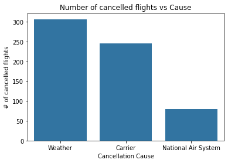

From the graph above, it is clear that **'A' (Carrier)** and **'B' (Weather)** are the highest reasons for flight cancellations.

## Which carrier had the most cancellations?

Once we have looked at the top reasons for cancellations, we can move on to see which carrier had the most cancellations. This can be observed by a bar plot for carrier codes for which flights were cancelled.

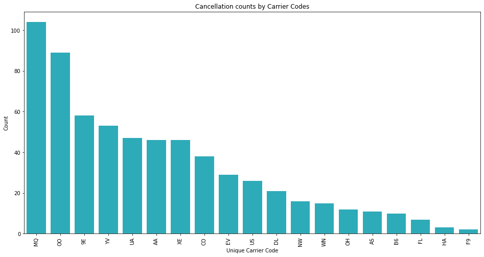

The plot above shows that **MQ(Envoy Air) and OO(SkyWest Airlines)** are the top carriers with highest cancellations. These cancellations include all three types (A,B,C).

### Univariate Distribution of Numerical Variables

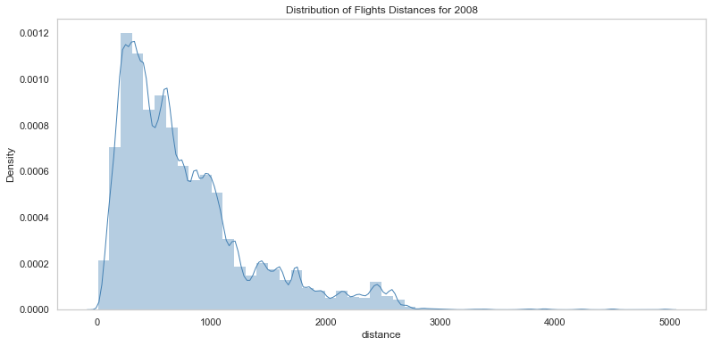

From this figure, we can see that the distribution of distances is a **Right Skewed Distribution** with some outlies with very high distaces.This means that most of the flights are small in distances.

## Bivariate Exploration

Now, Let's investigate relationships between two variables.

### What does each carrier's performance looks like in terms on on time arrivals?

Lets prepare a stacked bar chart that shows each carrier's on time performance.

We will use "arrival_delay" for this calculation. the flights that have **arrival_delays>0** were considered delayed. We will get the proportion of flights (for each carrier) that made it on time.

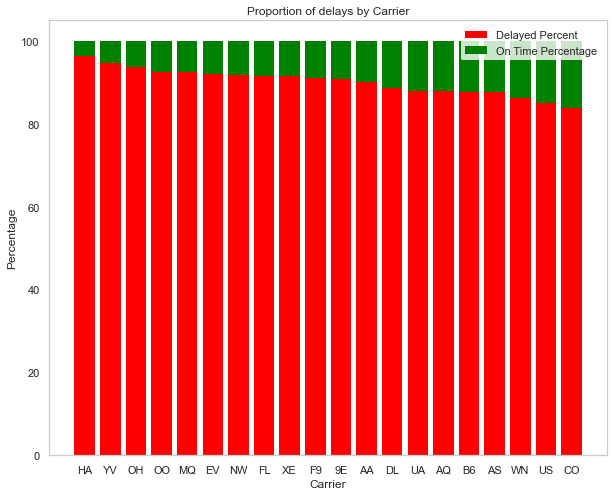

The red bars show delays as a percentage of total flights for each carrier. **The larger the red bar, The worse the performance.**

### What is the relationship between flight distances and mean arrival delay?

[figure not shown]

## Multivariate Exploration

Finally, we will investigate relationships between many variables.

### Does the number of flights to destinations have an effect on arrival delays?

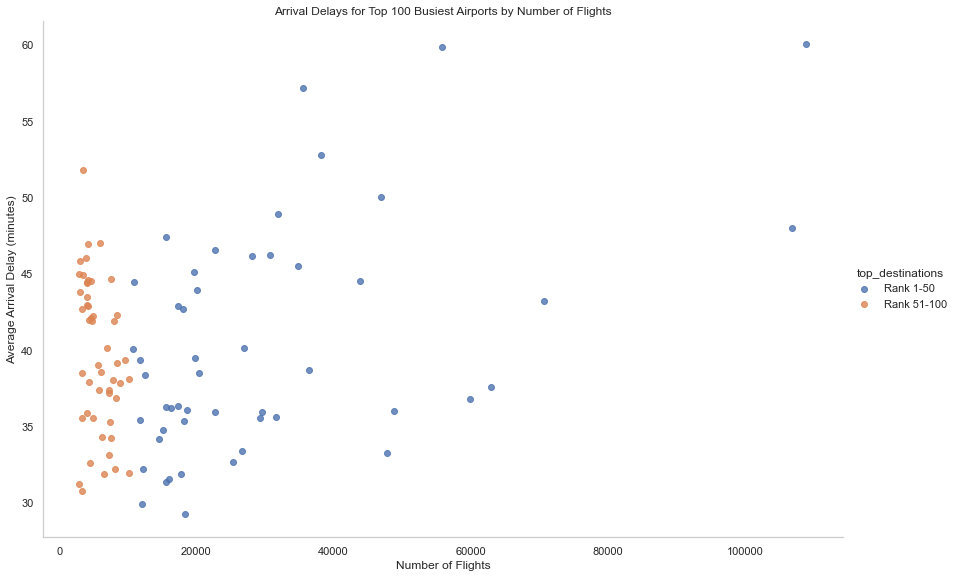

The graph above shows that for the top 50 busiest destinations, the number of flights does have an effect on average arrival delay. This is not so much true for less busy airports that rank from 51-100.

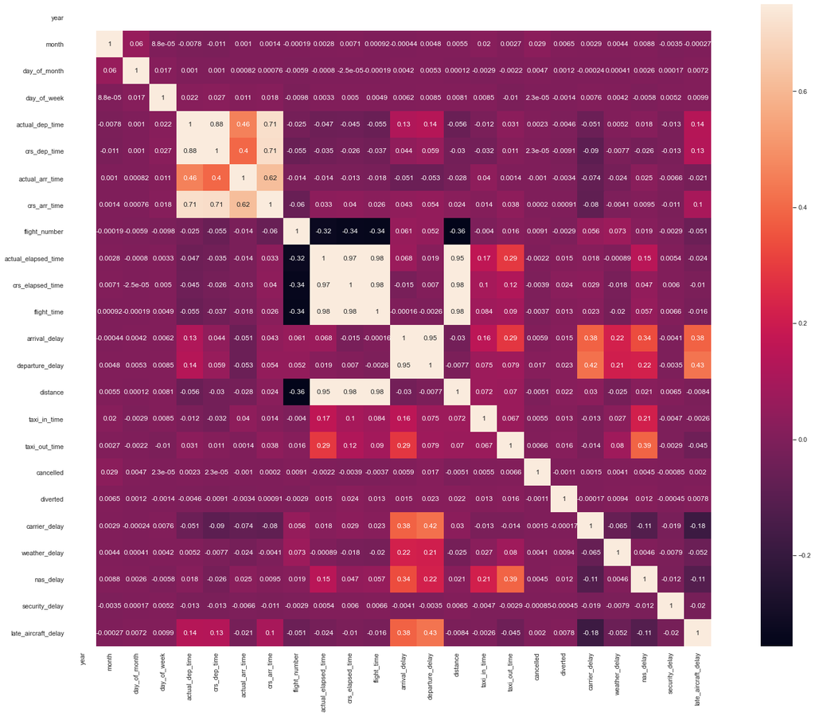